# NYT County-level covid-19 Data

Zach del Rosario 2020-05-30

This is an analysis of the New York Times [county-level covid-19 data](https://github.com/nytimes/covid-19-data). Additionally, I use US Census Data to normalize counts by 2018 population estimates.

# Setup

```r
library(tidyverse)
library(lubridate)
```

```r
url_counties <- "https://raw.githubusercontent.com/nytimes/covid-19-data/master/us-counties.csv"
filename_counties <- "./data/counties.csv"

filename_pop <- "./data/ACSDT5Y2018.B01003_data_with_overlays_2020-05-30T133451.csv"

theme_common <- function() {
  theme_minimal() %+replace%
  theme(
    axis.text.x = element_text(size = 12),
    axis.text.y = element_text(size = 12),
    axis.title.x = element_text(margin = margin(4, 4, 4, 4), size = 16),
    axis.title.y = element_text(margin = margin(4, 4, 4, 4), size = 16, angle = 90),

    legend.title = element_text(size = 16),
    legend.text = element_text(size = 12),

    strip.text.x = element_text(size = 12),
    strip.text.y = element_text(size = 12),

    panel.grid.major = element_line(color = "grey90"),
    panel.grid.minor = element_line(color = "grey90"),

    aspect.ratio = 4 / 4,

    plot.margin = unit(c(t = +0, b = +0, r = +0, l = +0), "cm"),
    plot.title = element_text(size = 18, hjust = 0),
    ## plot.title.position = "plot",
    plot.subtitle = element_text(size = 16),
    plot.caption = element_text(size = 12, hjust = 1)
  )
}
```

```r
curl::curl_download(
        url_counties,
        destfile = filename_counties
      )
```

```r
df_counties <- read_csv(filename_counties)
```

Additionally, I use the `2018: ACS 5-Year Estimates Detailed Tables` [Total Population](https://data.census.gov/cedsci/table?q=county%20population&g=0100000US.050000&hidePreview=false&tid=ACSDT5Y2018.B01003&t=Populations%20and%20People&vintage=2010) for county-level population estimates. Load those locally:

```r
df_pop <- read_csv(
  filename_pop,
  skip = 2,
  col_names = c(
    "id",
    "name",
    "population",
    "margin_of_error"
  )
) %>%
  mutate(
    fips = str_sub(id, -5, -1)
  )
```

# EDA

## First look

```r
df_counties %>% summary
```

```
##       date               county             state               fips
##  Min.   :2020-01-21   Length:570096      Length:570096      Length:570096
##  1st Qu.:2020-05-14   Class :character   Class :character   Class :character
##  Median :2020-06-29   Mode  :character   Mode  :character   Mode  :character
##  Mean   :2020-06-27
##  3rd Qu.:2020-08-12
##  Max.   :2020-09-25
##      cases            deaths
##  Min.   :     0   Min.   :    0.00
##  1st Qu.:    15   1st Qu.:    0.00
##  Median :    82   Median :    1.00
##  Mean   :  1006   Mean   :   37.87
##  3rd Qu.:   394   3rd Qu.:    9.00
##  Max.   :265775   Max.   :23792.00
```

**Observations**

Note that the NYT Readme states “If a county is not listed for a date, then there were zero reported confirmed cases and deaths.” For instance:

```r
df_counties %>% filter(cases == 0, deaths == 0)
```

```
## # A tibble: 0 x 6
## # … with 6 variables: date <date>, county <chr>, state <chr>, fips <chr>,
## #   cases <dbl>, deaths <dbl>
```

## Variables

```r
df_counties %>% glimpse
```

```
## Rows: 570,096
## Columns: 6
## $ date   <date> 2020-01-21, 2020-01-22, 2020-01-23, 2020-01-24, 2020-01-24, 2…
## $ county <chr> "Snohomish", "Snohomish", "Snohomish", "Cook", "Snohomish", "O…
## $ state  <chr> "Washington", "Washington", "Washington", "Illinois", "Washing…
## $ fips   <chr> "53061", "53061", "53061", "17031", "53061", "06059", "17031",…
## $ cases  <dbl> 1, 1, 1, 1, 1, 1, 1, 1, 1, 1, 1, 1, 1, 1, 1, 1, 1, 1, 1, 1, 1,…
## $ deaths <dbl> 0, 0, 0, 0, 0, 0, 0, 0, 0, 0, 0, 0, 0, 0, 0, 0, 0, 0, 0, 0, 0,…
```

| Variable | Description |
| --- | --- |
| `date` | Date of data update |
| `county` | Name of reporting county |
| `state` | Name of state |
| `fips` | Federal Information Processing System code (UID) |
| `cases` | Cumulative cases, both [confirmed and probable](https://github.com/nytimes/covid-19-data/blob/master/PROBABLE-CASES-NOTE.md) |
| `deaths` | Cumulative deaths due to covid-19; NYT non-specific as to confirmed vs probable |

As of writing, there are `3143` counties in the 50 US states. How many counties do we have data for?

```r
df_counties %>%
  filter(!is.na(fips)) %>%
  pull(fips) %>%
  unique %>%
  length
```

```
## [1] 3210
```

## Exceptions

There are some oddities in these data: From poking around I found some entries with `NA` fips:

```r
df_counties %>%
  filter(is.na(fips)) %>%
  count(county, state) %>%
  arrange(desc(n))
```

```
## # A tibble: 54 x 3
##    county        state             n
##    <chr>         <chr>         <int>
##  1 New York City New York        209
##  2 Unknown       Rhode Island    209
##  3 Unknown       New Jersey      198
##  4 Unknown       Puerto Rico     197
##  5 Unknown       Guam            195
##  6 Unknown       Massachusetts   194
##  7 Unknown       Louisiana       192
##  8 Kansas City   Missouri        190
##  9 Unknown       Arkansas        190
## 10 Unknown       Georgia         189
## # … with 44 more rows
```

**Observations**

- NYC is given its own category
- Some territories are reported in the `state` column; these do not have county-level fips codes
- Kansas City has a community fips code, but it is part of Jackson County
- From the NYT documentation, “Many state health departments choose to report cases separately when the patient’s county of residence is unknown or pending determination. In these instances, we record the county name as”Unknown.""

## Source dates

Undoubtedly, the data reporting from each county have different temporality. Let’s inspect:

```r
df_duration <-
  df_counties %>%
  group_by(fips) %>%
  summarize(
    date_min = min(date),
    date_max = max(date)
  ) %>%
  mutate(
    span = date_max - date_min,
    fips = fct_reorder(fips, span)
  )
```

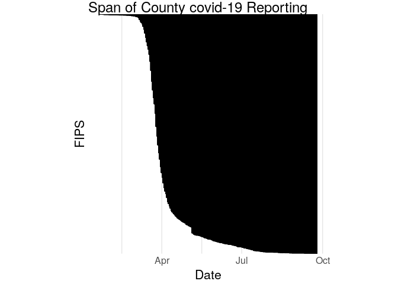

```r
df_duration %>%
  ggplot() +
  geom_segment(aes(x = date_min, xend = date_max, y = fips, yend = fips)) +

  scale_y_discrete(breaks = c()) +
  theme_common() +
  labs(
    x = "Date",
    y = "FIPS",
    title = "Span of County covid-19 Reporting"
  )
```

**Observations**

- The earliest county-level reports are in early 2020; the NYT documentation puts the first case at Washington State on Jan. 21, 2020
- The latest county reports appear to be just a few days ago

We can get a better sense of the start dates via a histogram.

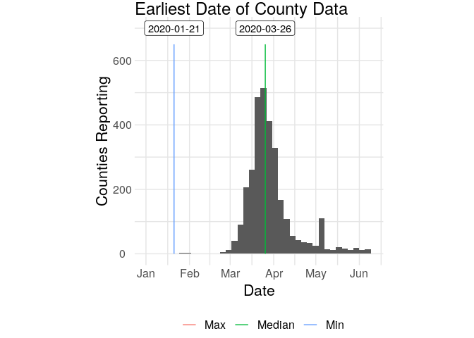

```r
n_top <- 650 # Where to place labels

df_duration_stat <-
  df_duration %>%
  summarize(
    Min = min(date_min),
    Median = median(date_min),
    Max = max(date_min)
  ) %>%
  pivot_longer(
    names_to = "stat",
    values_to = "date_min",
    everything()
  )

df_duration %>%
  ggplot() +
  geom_histogram(aes(date_min), bins = 40) +
  geom_segment(
    data = df_duration_stat,
    mapping = aes(x = date_min, xend = date_min, y = 0, yend = n_top, color = stat)
  ) +
  geom_label(
    data = df_duration_stat,
    mapping = aes(x = date_min, y = n_top + 50, label = date_min)
  ) +

  scale_x_date(limits = c(ymd("2020-01-01", "2020-06-10"))) +
  scale_color_discrete(name = "") +
  theme_common() +
  theme(legend.position = "bottom") +
  labs(
    x = "Date",
    y = "Counties Reporting",
    title = "Earliest Date of County Data"
  )
```

**Obserations**

## Population

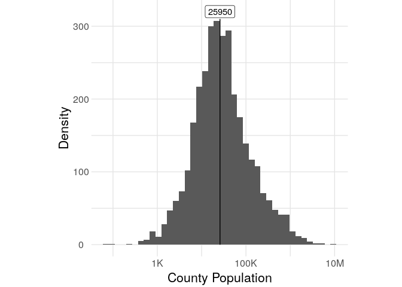

```r
n_count <- 310
pop_median <-
  df_pop %>%
  summarize(across(population, median)) %>%
  pull(population) %>%
  round()

df_pop %>%

  ggplot(aes(population)) +
  geom_histogram(bins = 40) +
  annotate(
    "segment",
    x = pop_median, xend = pop_median, y = 0, yend = n_count
  ) +
  annotate(
    "label",
    x = pop_median, y = n_count + 10, label = pop_median
  ) +

  scale_x_log10(labels = scales::label_number_si()) +
  theme_common() +
  labs(
    x = "County Population",
    y = "Density"
  )
```

**Observations**

- The distribution of county populations is approximately lognormal
- Small counties are around `1000` persons
- The median county size is `25950` persons
- The largest county is about `10` million persons

# Trends

To study trends in the number of cases, I first turn the implicit zero-counts into explicit zeros.

```r
df_cases_filled <-
  df_counties %>%
  select(date, county, state, fips, cases) %>%
  pivot_wider(
    names_from = date,
    names_sep = "_",
    values_from = cases,
    values_fill = 0
  ) %>%
  pivot_longer(
    names_to = "date",
    values_to = "cases",
    -c(county, state, fips)
  ) %>%
  left_join(
    .,
    df_pop %>% select(fips, population),
    by = "fips"
  ) %>%
  mutate(
    date = ymd(date),
    cases_per_100k = cases / population * 100000
  )
```

Visualize all the county data

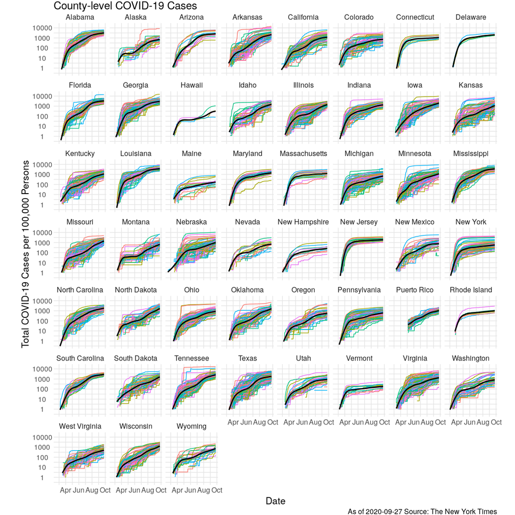

```r
n_roll <- 5
cpk_min <-
  df_cases_filled %>%
  filter(cases_per_100k > 0) %>%
  pull(cases_per_100k) %>%
  min

df_cases_filled %>%
  filter(
    !is.na(fips),
    state != "District of Columbia"
  ) %>%
  group_by(state) %>%
  mutate(id = as.factor((dense_rank(as.integer(fips))) %% n_roll)) %>%
  filter(cases_per_100k >= 1) %>%
  ungroup() %>%

  ggplot(aes(date, cases_per_100k, group = fips, color = id)) +
  geom_line(size = 0.5) +
  geom_smooth(aes(group = state), se = FALSE, color = "black", size = 1) +

  scale_x_date(breaks = "2 months", date_labels = "%b") +
  scale_y_log10() +
  facet_wrap(~state) +
  guides(color = "none") +
  theme_common() +
  labs(
    x = "Date",
    y = "Total COVID-19 Cases per 100,000 Persons",
    title = "County-level COVID-19 Cases",
    caption = str_c("As of ", today(), " Source: The New York Times")
  )
```

**Observations**

Day-to-day trends

```
## Warning: Removed 14632 rows containing non-finite values (stat_smooth).


## Warning: Removed 14632 rows containing non-finite values (stat_smooth).
```

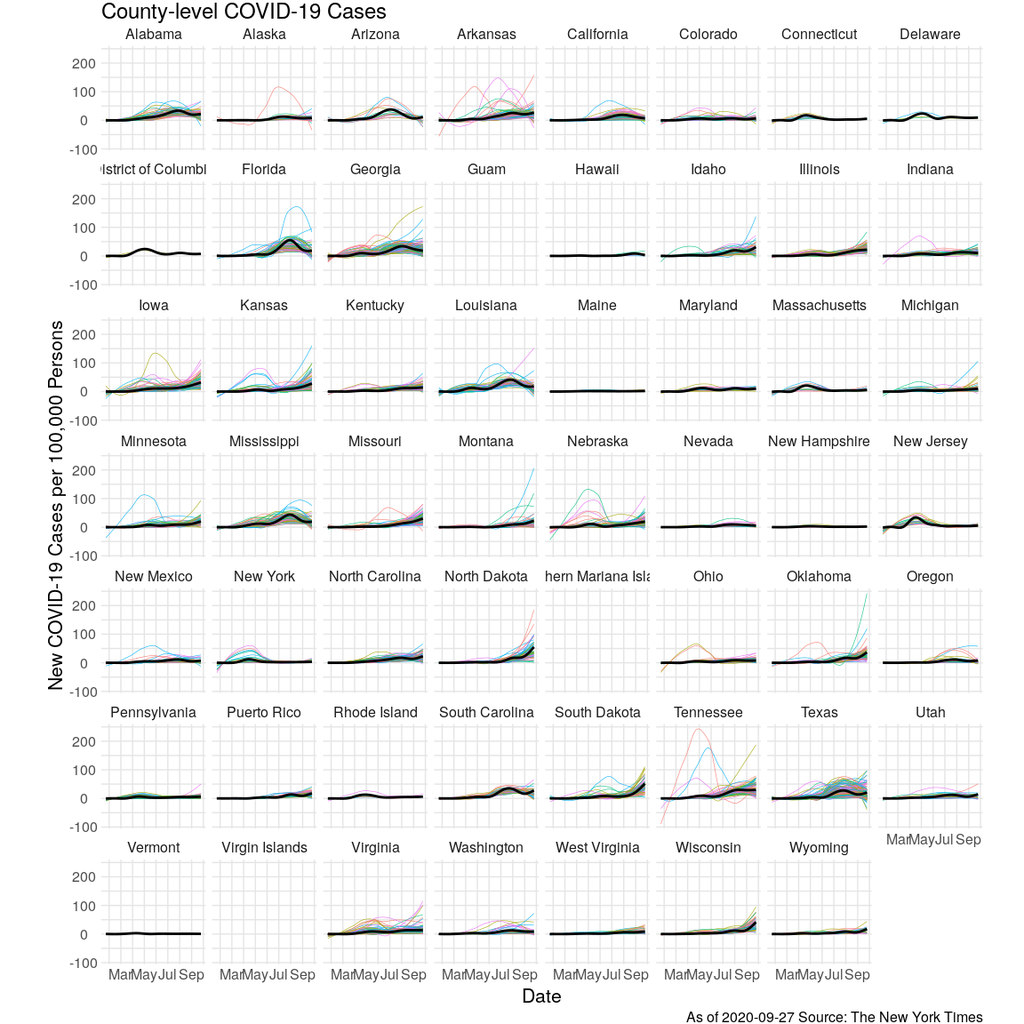

```r
df_cases_filled %>%
  group_by(county, state) %>%
  arrange(date) %>%
  mutate(
    delta = cases - lag(cases),
    delta = if_else(delta < 0, 0, delta),
    delta_per_100k = delta / population * 100000
  ) %>%
  filter(!is.na(delta)) %>%
  ungroup() %>%
  group_by(state) %>%
  mutate(id = as.factor((dense_rank(as.integer(fips))) %% n_roll)) %>%
  ungroup() %>%

  ggplot(aes(date, delta_per_100k, group = fips, color = id)) +
  ## geom_line(size = 0.5) +
  geom_smooth(aes(color = id), se = FALSE, size = 0.2) +
  geom_smooth(aes(group = state), se = FALSE, color = "black", size = 1) +

  scale_x_date(breaks = "2 months", date_labels = "%b") +
  ## scale_y_log10() +
  facet_wrap(~state) +
  guides(color = "none") +
  theme_common() +
  labs(
    x = "Date",
    y = "New COVID-19 Cases per 100,000 Persons",
    title = "County-level COVID-19 Cases",
    caption = str_c("As of ", today(), " Source: The New York Times")
  )
```

### State-level data

```r
plot_cpk <- function(state_name, n_max = 3) {
  top_counties <-
    df_cases_filled %>%
    filter(state == state_name, date == max(date)) %>%
    group_by(county) %>%
    summarize(cpk = median(cases_per_100k)) %>%
    filter(dense_rank(-cpk) <= n_max) %>%
    pull(county)

  bot_counties <-
    df_cases_filled %>%
    filter(state == state_name, date == max(date)) %>%
    group_by(county) %>%
    summarize(cpk = median(cases_per_100k)) %>%
    filter(dense_rank(cpk) <= n_max) %>%
    pull(county)

  df_cases_filled %>%
    filter(
      state == state_name,
      cases_per_100k >= 1
    ) %>%
    mutate(county = fct_reorder2(county, date, cases_per_100k)) %>%

    ggplot(aes(date, cases_per_100k)) +
    geom_line(
      aes(group = county),
      size = 0.5,
      color = "grey80"
    ) +
    geom_line(
      data = . %>% filter(county %in% c(top_counties, bot_counties)),
      mapping = aes(color = county),
      size = 0.5
    ) +
    geom_smooth(aes(group = state), se = FALSE, color = "black", size = 1) +

    scale_x_date(labels = scales::label_date("%m / %d"), date_breaks = "20 days") +
    scale_y_log10() +
    scale_color_discrete(name = "County") +
    theme_common() +
    labs(
      x = "Date",
      y = "Total COVID-19 Cases per 100,000 Persons",
      title = str_c("County-level COVID-19 Cases in ", state_name),
      caption = str_c("As of ", today(), " Source: The New York Times")
    )
}
```

Compute new cases

```r
plot_new_cpk <- function(state_name, n_max = 3) {
  df_state_new <-
    df_cases_filled %>%
    filter(state == state_name) %>%
    group_by(county) %>%
    arrange(date) %>%
    mutate(
      delta = cases - lag(cases),
      delta = if_else(delta < 0, 0, delta),
      delta_per_100k = delta / population * 100000
    ) %>%
    filter(!is.na(delta)) %>%
    ungroup() %>%
    mutate(id = as.factor((dense_rank(as.integer(fips))) %% n_roll))

  top_counties <-
    df_state_new %>%
    filter(date == max(date)) %>%
    group_by(county) %>%
    summarize(dpk = median(delta_per_100k)) %>%
    filter(dense_rank(-dpk) <= n_max) %>%
    pull(county)

  bot_counties <-
    df_state_new %>%
    filter(date == max(date)) %>%
    group_by(county) %>%
    summarize(dpk = median(delta_per_100k)) %>%
    filter(dense_rank(dpk) <= n_max) %>%
    pull(county)

  df_state_new %>%
    mutate(county = fct_reorder2(county, date, delta_per_100k)) %>%

    ggplot(aes(date, delta_per_100k)) +
    geom_step(
      aes(group = county),
      size = 0.5,
      color = "grey80"
    ) +
    geom_step(
      data = . %>% filter(county %in% c(top_counties, bot_counties)),
      mapping = aes(color = county),
      size = 0.5
    ) +
    geom_smooth(aes(group = state), se = FALSE, color = "black", size = 1) +

    scale_x_date(labels = scales::label_date("%m / %d"), date_breaks = "30 days") +
    scale_color_discrete(name = "County") +
    theme_common() +
    labs(
      x = "Date",
      y = "New COVID-19 Cases per 100,000 Persons",
      title = str_c("County-level COVID-19 Cases in ", state_name),
      caption = str_c("As of ", today(), " Source: The New York Times")
    )
}
```

### Arkansas

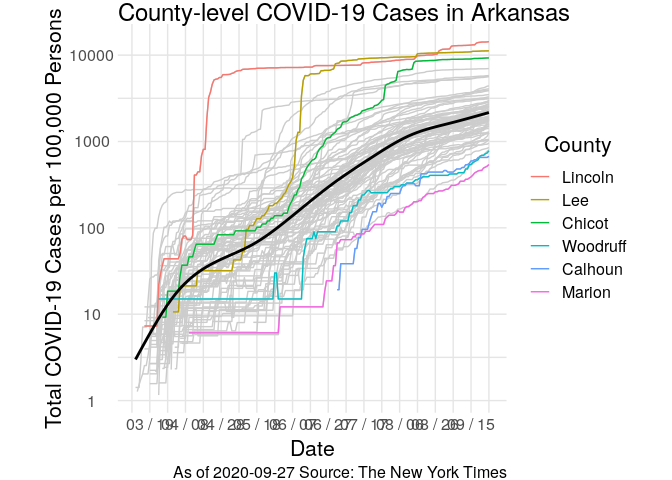

```r
plot_cpk("Arkansas")
```

**Observations**

- Lincoln County
  - With population 13695, this is a small county
  - Apparently April testing in [prisons](https://www.themarshallproject.org/2020/04/24/these-prisons-are-doing-mass-testing-for-covid-19-and-finding-mass-infections) uncovered many cases, which accounts for the increase

```
## Warning: Removed 248 rows containing non-finite values (stat_smooth).

## Warning: Removed 248 row(s) containing missing values (geom_path).
```

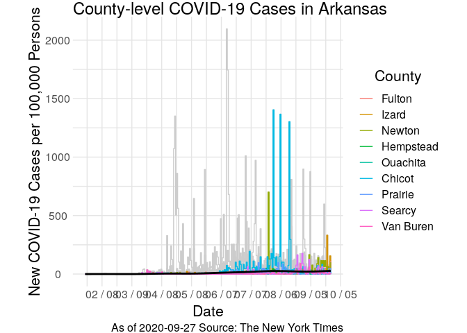

```r
plot_new_cpk("Arkansas")
```

### California

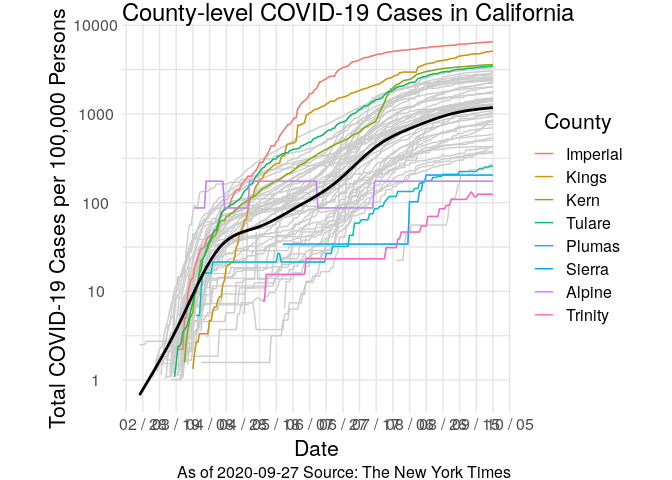

```r
plot_cpk("California", n_max = 4)
```

**Observations**

- Imperial County has a per-capita rate of infection so high, that some residents are being transported to [San Francisco](https://www.sandiegouniontribune.com/news/story/2020-06-14/imperial-county-has-highest-rate-of-covid-19-cases-in-the-state-it-wants-to-reopen-anyway)
- There was an outbreak in [Avenal Prison](https://www.fresnobee.com/news/coronavirus/article242975596.html) back in late May, but that probably doesn’t account for the continued increase in cases

```
## Warning: Removed 248 rows containing non-finite values (stat_smooth).

## Warning: Removed 248 row(s) containing missing values (geom_path).
```

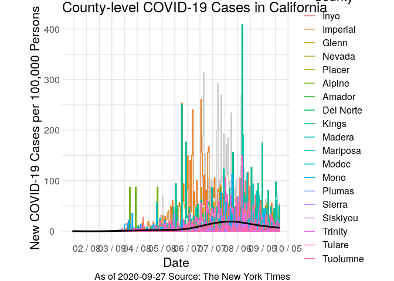

```r
plot_new_cpk("California")
```

### Florida

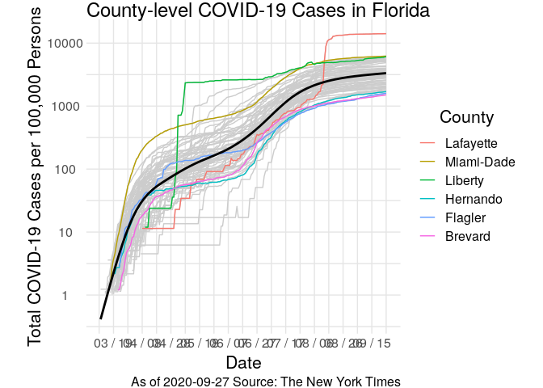

```r
plot_cpk("Florida")
```

```
## Warning: Removed 248 rows containing non-finite values (stat_smooth).

## Warning: Removed 248 row(s) containing missing values (geom_path).
```

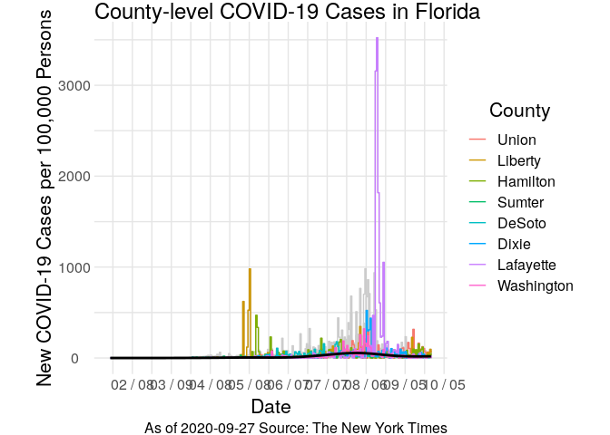

```r
plot_new_cpk("Florida")
```

### Idaho

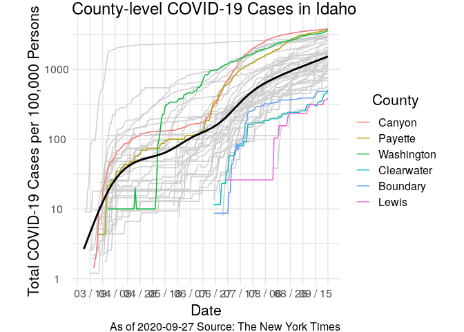

```r
plot_cpk("Idaho")
```

- Blaine County
  - With population 21994, this is a medium county
  - This [Buzzfeed article](https://www.buzzfeednews.com/article/annehelenpetersen/coronavirus-covid-19-idaho-blaine-county-sun-valley) notes that Blaine is not so different from other counties, but was hit earlier than many other counties
- Washington County
  - With population 10025, this is a small county
  - Apparently there was a cluster of covid-19 cases in Washington county due to a [family gathering](https://localnews8.com/health/coronavirus/2020/05/13/official-idaho-virus-outbreak-linked-to-family-gathering/)

```
## Warning: Removed 248 rows containing non-finite values (stat_smooth).

## Warning: Removed 248 row(s) containing missing values (geom_path).
```

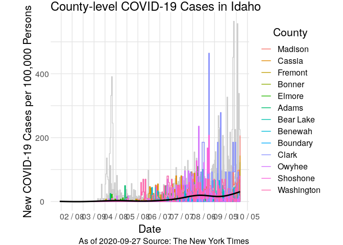

```r
plot_new_cpk("Idaho")
```

### Massachusetts

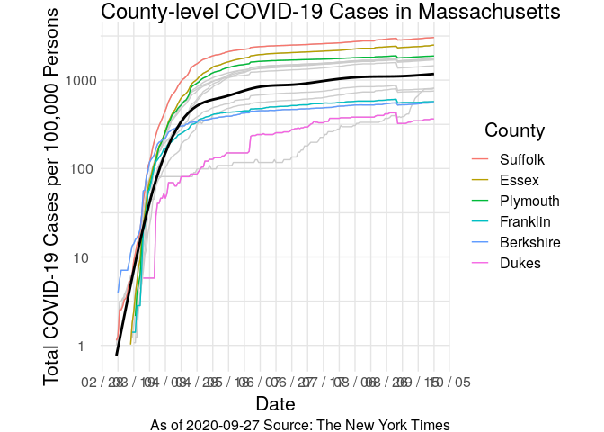

```r
plot_cpk("Massachusetts")
```

**Observations**

- Massachusetts seems to have flattened the curve!

```
## Warning: Removed 248 rows containing non-finite values (stat_smooth).

## Warning: Removed 248 row(s) containing missing values (geom_path).
```

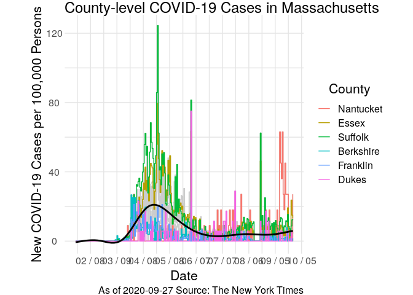

```r
plot_new_cpk("Massachusetts")
```

### Minnesota

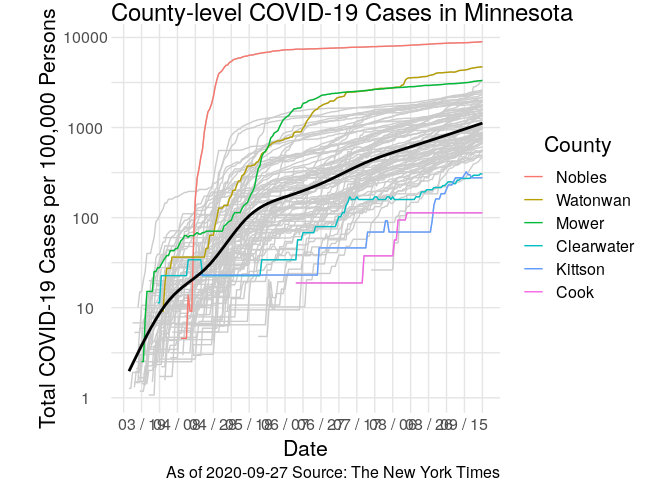

```r
plot_cpk("Minnesota")
```

```
## Warning: Removed 248 rows containing non-finite values (stat_smooth).

## Warning: Removed 248 row(s) containing missing values (geom_path).
```

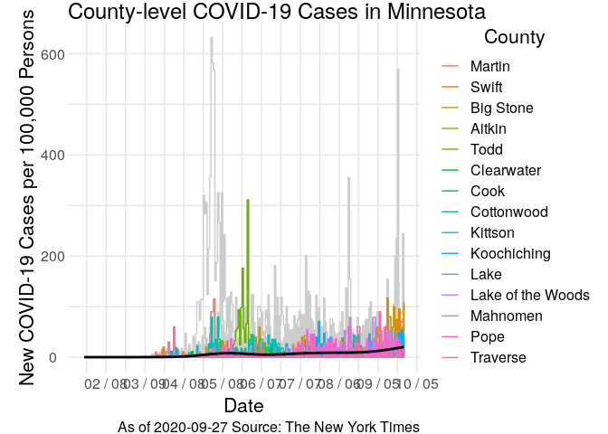

```r
plot_new_cpk("Minnesota")
```

### Ohio

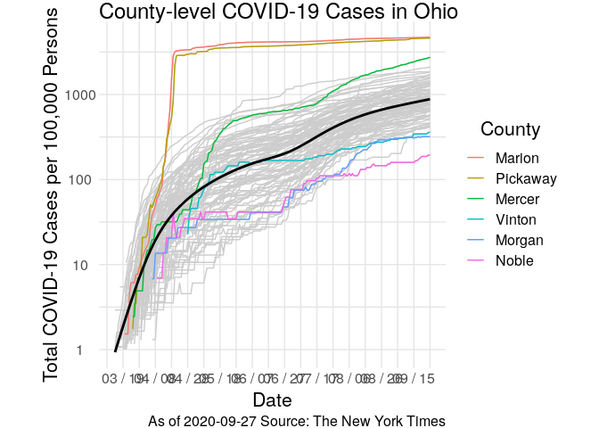

```r
plot_cpk("Ohio")
```

- Marion County
  - With population 65344, this is a medium county
  - About [75% of inmates](https://www.cleveland.com/open/2020/04/marion-county-not-cuyahoga-county-now-leads-ohio-in-reported-coronavirus-cases-heres-why.html) in Marion Correctional Center tested positive for covid-19
- Pickaway County
  - With population 57420, this is a medium county
  - [Pickaway Correctional Institution](https://www.dispatch.com/news/20200422/coronavirus-surges-at-pickaway-prison-now-no-2-hot-spot-in-nation---behind-marion-prison) also has a large number of cases

```
## Warning: Removed 248 rows containing non-finite values (stat_smooth).

## Warning: Removed 248 row(s) containing missing values (geom_path).
```

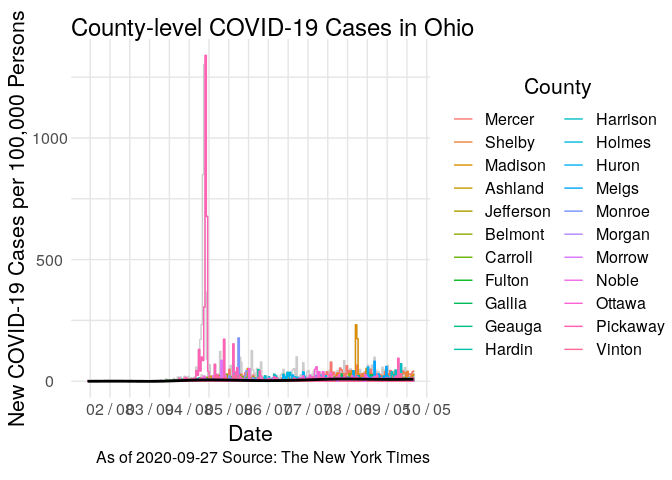

```r
plot_new_cpk("Ohio")
```

### Tennessee

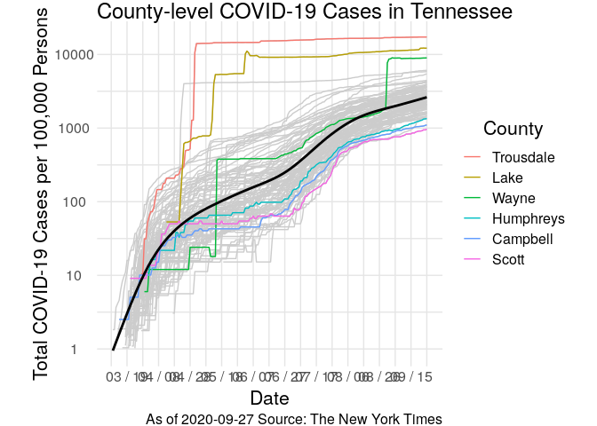

```r
plot_cpk("Tennessee")
```

- Trousdale County
  - With population 9573, this is a tiny county
  - The early-May spike can be attributed to cases in [Trousdale Turner Correctional Center](https://communityimpact.com/nashville/southwest-nashville/coronavirus/2020/05/01/large-spike-in-coronavirus-cases-traced-to-prison-in-trousdale-county/)
- Lake County
  - With population 7526, this is a tiny county
  - There are multiple jumps in case count, first in April, then again in May
  - Reports go back as far as April about cases in the [Northwest Correctional Complex](https://www.kfvs12.com/2020/04/23/lake-county-covid-cases-double-one-day/)
  - A majority of cases by May were in the [Northwest Correctional Complex](https://www.kfvs12.com/2020/05/14/covid-cases-lake-county-tenn-linked-northwest-correctional-complex/)
- Bledsoe County
  - With population 14602, this is a medium county
  - Cases jumped in [April](https://wdef.com/2020/04/24/bledsoe-prison-warping-covid-19-case-stats-county/) due to cases in Bledsoe County Regional Facility

```
## Warning: Removed 248 rows containing non-finite values (stat_smooth).

## Warning: Removed 248 row(s) containing missing values (geom_path).
```

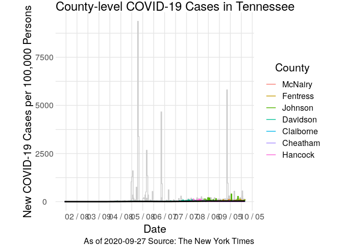

```r
plot_new_cpk("Tennessee")
```

### Texas

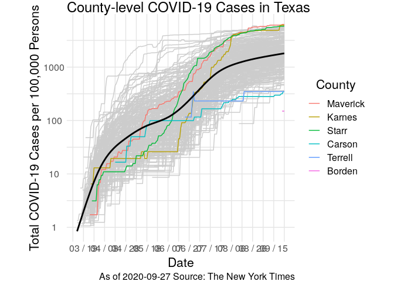

```r
plot_cpk("Texas")
```

```
## Warning: Removed 248 rows containing non-finite values (stat_smooth).

## Warning: Removed 248 row(s) containing missing values (geom_path).
```

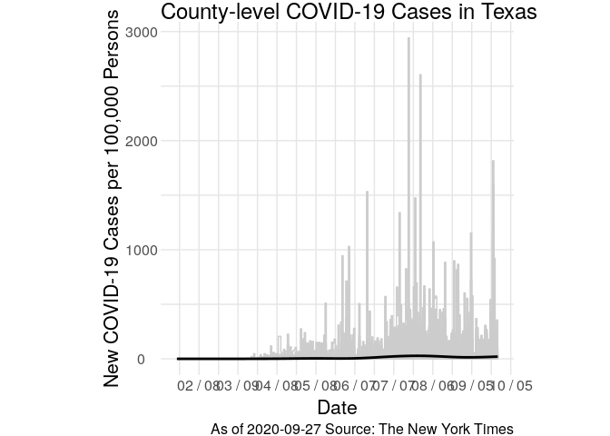

```r
plot_new_cpk("Texas", n_max = 0)
```